# Clustering: earthquakes in Fiji

K-means, EM and spectral clustering on the same cloud, judged by stability – and why the most stable partition is not the most informative one.

The other vignettes are listed by `vignette (package = "fdm2id")`; they use the same handful of functions on other data, and can be read in any order.

```r
library (fdm2id)
```

# The data

Measurements from Harvard University’s department of geophysics on seismic activity near Fiji. Each observation is one recorded earthquake. The first two descriptors are the geographical coordinates of the epicentre, the third its depth and the fourth its magnitude. The fifth is not used.

The clustering is done on the geographical coordinates only, with $K$-means, EM and spectral clustering. A first look at the data suggests three clusters.

```r
data (quakes, package = "datasets")
summary (quakes [, -5])
```

```
#>       lat              long           depth            mag
#>  Min.   :-38.59   Min.   :165.7   Min.   : 40.0   Min.   :4.00
#>  1st Qu.:-23.47   1st Qu.:179.6   1st Qu.: 99.0   1st Qu.:4.30
#>  Median :-20.30   Median :181.4   Median :247.0   Median :4.60
#>  Mean   :-20.64   Mean   :179.5   Mean   :311.4   Mean   :4.62
#>  3rd Qu.:-17.64   3rd Qu.:183.2   3rd Qu.:543.0   3rd Qu.:4.90
#>  Max.   :-10.72   Max.   :188.1   Max.   :680.0   Max.   :6.40
```

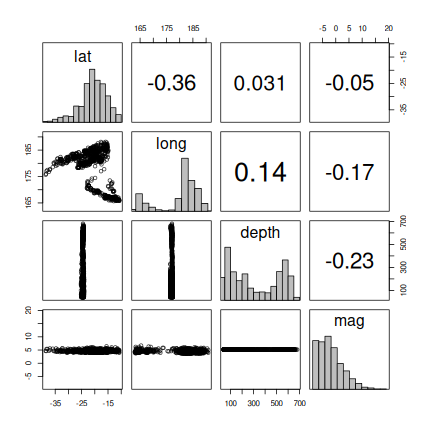

```r
plotdata (quakes [, -5])
```

The two coordinates on their own, which is what the clustering will see:

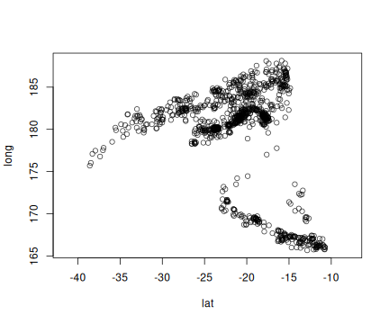

```r
plotdata (quakes [, 1:2], type = "scatter")
```

# Question 1. Which method produces the most stable clusters?

```r
# Variable, all three: K-means starts from random centres, EM from a random initialisation,
# and spectral clustering ends on a K-means in the eigenvector space. Without 'seed', the
# cluster numbering alone changes from run to run -- so every "cluster 3" below would have to
# be re-read against the picture.
km = KMEANS (quakes [, 1:2], k = 3, seed = 0)
em = EM (quakes [, 1:2], k = 3, seed = 0)
sc = SPECTRAL (quakes [, 1:2], k = 3, sigma = .5, seed = 0)
```

`stability` re-runs each method on bootstrap resamples and measures, cluster by cluster, how much of the original cluster survives.

```r
# Variable: the resampling, plus the method re-run on each resample. The same 'seed' is given
# to the three calls so that they compare the methods on the same resamples.
stability (KMEANS, quakes [, 1:2], km, k = 3, seed = 0)
```

```
#>             jaccard
#> Cluster 1 0.9985544
#> Cluster 2 0.9718064
#> Cluster 3 0.9860323
```

```r
stability (EM, quakes [, 1:2], em, k = 3, seed = 0)
```

```
#>             jaccard
#> Cluster 1 0.9969824
#> Cluster 2 0.8712408
#> Cluster 3 0.9084557
```

```r
stability (SPECTRAL, quakes [, 1:2], sc, k = 3, sigma = .5, seed = 0)
```

```
#>             jaccard
#> Cluster 1 0.6600194
#> Cluster 2 0.4193419
#> Cluster 3 0.9954400
```

**Answer.** *$K$-means produces the most stable clusters. EM’s are slightly less stable. Spectral clustering gives the least stable result – and the per-cluster figures say where: one of its three clusters barely survives resampling at all.*

# Question 2. How do the clusters read in depth and magnitude?

The clustering used the coordinates only. Depth and magnitude are therefore *external* variables here, and describing the clusters by them is what turns a partition into a result.

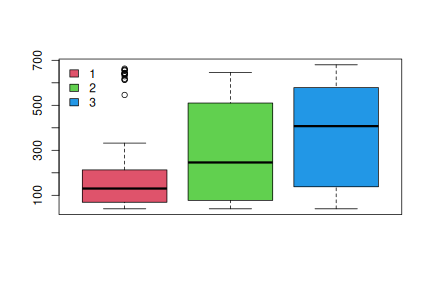

```r
plotdata (quakes [, "depth"], km$cluster, type = "boxplot")
```

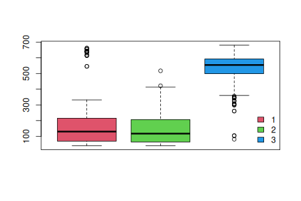

```r
plotdata (quakes [, "depth"], em$cluster, type = "boxplot")
```

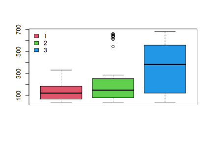

```r
plotdata (quakes [, "depth"], sc$cluster, type = "boxplot")
```

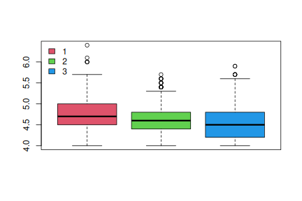

```r
plotdata (quakes [, "mag"], km$cluster, type = "boxplot")
```

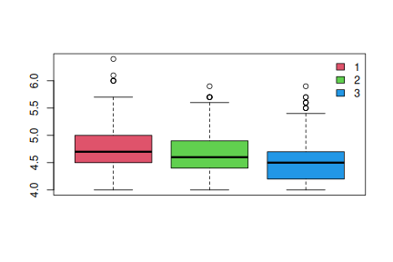

```r
plotdata (quakes [, "mag"], em$cluster, type = "boxplot")
```

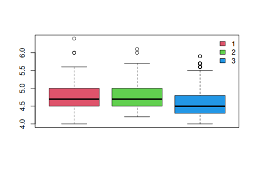

```r
plotdata (quakes [, "mag"], sc$cluster, type = "boxplot")
```

# Question 3. Where are the shallowest earthquakes? The deepest?

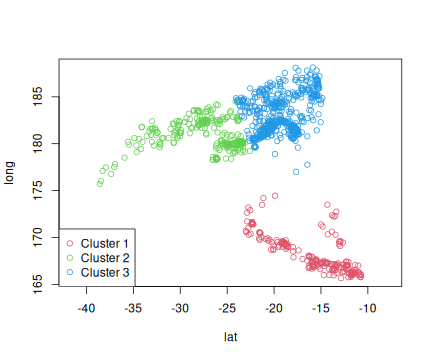

```r
plotclus (km, quakes [, 1:2])
```

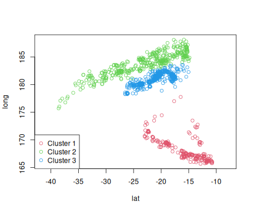

```r
plotclus (em, quakes [, 1:2])
```

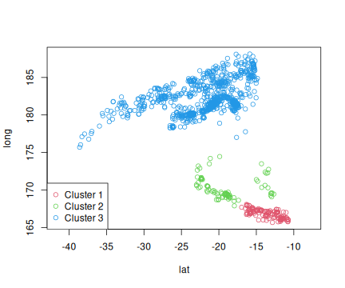

```r
plotclus (sc, quakes [, 1:2])
```

Next to the same map, coloured by depth rather than by cluster:

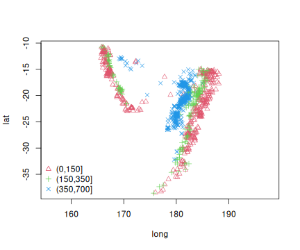

```r
plotdata (quakes [, 2:1], cut (quakes$depth, c (0, 150, 350, 700)), type = "scatter")
```

**Answer.** *All three methods agree on one thing – a sparse western arc, and a much denser eastern region – and disagree on how to cut the rest. The depth map says where the answer is: in the east, the deep earthquakes lie on an inner band and the shallow ones along the outer edge, which is the profile of a subduction zone seen from above. EM is the only one of the three that cuts along that line. $K$-means cuts the eastern region by latitude instead, across the depth gradient rather than along it, and spectral clustering leaves the east in one piece and spends its two other clusters splitting the western arc.*

# Question 4. How many clusters are there really?

The deep earthquakes are not confined to the eastern region:

```r
west = quakes [quakes$long < 176, ]
table (deep = west$depth > 350)
```

```
#> deep
#> FALSE  TRUE
#>   191    15
```

```r
round (apply (west [west$depth > 350, 1:2], 2, range), 1)
```

```
#>        lat  long
#> [1,] -19.9 169.1
#> [2,] -12.7 174.5
```

**Answer.** *Four. Depth splits the eastern region in two – the deep inner band and the shallow outer edge – and the western arc holds, besides its shallow earthquakes, a small patch of very deep ones some 600 km down. Asking any method for three clusters forces it to merge two of those four: EM merges the western pair, spectral clustering merges the eastern pair.*

# Question 5. Which methods give the most relevant clusters?

**Answer.** *EM and spectral clustering – which is not the ranking question 1 gave. Each of them found a real boundary that $K$-means did not, and their instability is a symptom of that: they are fitting a structure that a bootstrap resample does not reproduce exactly, where $K$-means cuts a compact, reproducible partition out of a cloud whose real structure is not spherical. Stability measures how reliably a method returns the same answer, not whether the answer is the right one.*